# Data Science Challenge

```python
# To install packages that are not installed by default, uncomment the last two lines
# of this cell and replace <package list> with a list of necessary packages.
# This will ensure the notebook has all the dependencies and works everywhere.

import sys
!{sys.executable} -m pip install
```

```python
pip install numpy --upgrade
```

```python
#Libraries
import pandas as pd
import numpy as np
import matplotlib.pyplot as plt
import seaborn as sns
from sklearn.model_selection import train_test_split, GridSearchCV
from sklearn.preprocessing import StandardScaler, OrdinalEncoder
from sklearn.linear_model import LogisticRegression
from sklearn.svm import SVC
from sklearn.ensemble import RandomForestClassifier
from xgboost import XGBClassifier
import missingno as msno
from sklearn.preprocessing import LabelEncoder



import warnings
warnings.filterwarnings('ignore')

pd.set_option("display.max_columns", 101)
```

[output not shown]

[output cut: 14 more lines]

## Data Description

| Column | Description |
| --- | --- |
| `id` | The unique ID assigned to every hotel. |
| `region` | The region in which the hotel is located.. |
| `latitude` | The latitude of the hotel. |
| `longitude` | The longitude of the hotel. |
| `accommodation_type` | The type of accommodation offered by the hotel. For example: Private room, Entire house/apt, etc. |
| `cost` | The cost of booking the hotel for one night. (in \$\$) |
| `minimum_nights` | The minimum number of nights stay required. |
| `number_of_reviews` | The number of reviews accumulated by the hotel. |
| `reviews_per_month` | The average number of reviews received by the hotel per month. |
| `owner_id` | The unique ID assigned to every owner. An owner can own multiple hotels. |
| `owned_hotels` | The number of hotels owned by the owner. |
| `yearly_availability` | It indicates if the hotel accepts bookings around the year. Values are 0 (not available for 365 days in a year) and 1 (available for 365 days in a year). |

## Data Wrangling & Visualization

```python
# Dataset is already loaded below
data = pd.read_csv("train.csv")
```

```python
data.head()
```

|  | id | region | latitude | longitude | accommodation_type | cost | minimum_nights | number_of_reviews | reviews_per_month | owner_id | owned_hotels | yearly_availability |
| --- | --- | --- | --- | --- | --- | --- | --- | --- | --- | --- | --- | --- |
| 0 | 13232 | Manhattan | 40.71854 | -74.00439 | Entire home/apt | 170 | 5 | 7 | 0.56 | 929983 | 1 | 0 |
| 1 | 246 | Brooklyn | 40.64446 | -73.95030 | Entire home/apt | 65 | 3 | 238 | 2.30 | 281764 | 1 | 0 |
| 2 | 19091 | Queens | 40.78573 | -73.81062 | Private room | 85 | 1 | 0 | NaN | 19923341 | 1 | 1 |
| 3 | 34305 | Manhattan | 40.73863 | -73.98002 | Private room | 210 | 30 | 0 | NaN | 200380610 | 65 | 1 |
| 4 | 444 | Manhattan | 40.82426 | -73.94630 | Shared room | 75 | 3 | 38 | 0.42 | 745069 | 3 | 1 |

```python
#Explore columns
data.columns
```

```
Index(['id', 'region', 'latitude', 'longitude', 'accommodation_type', 'cost',
       'minimum_nights', 'number_of_reviews', 'reviews_per_month', 'owner_id',
       'owned_hotels', 'yearly_availability'],
      dtype='object')
```

```python
#Description
data.head()
```

|  | id | region | latitude | longitude | accommodation_type | cost | minimum_nights | number_of_reviews | reviews_per_month | owner_id | owned_hotels | yearly_availability |
| --- | --- | --- | --- | --- | --- | --- | --- | --- | --- | --- | --- | --- |
| 0 | 13232 | Manhattan | 40.71854 | -74.00439 | Entire home/apt | 170 | 5 | 7 | 0.56 | 929983 | 1 | 0 |
| 1 | 246 | Brooklyn | 40.64446 | -73.95030 | Entire home/apt | 65 | 3 | 238 | 2.30 | 281764 | 1 | 0 |
| 2 | 19091 | Queens | 40.78573 | -73.81062 | Private room | 85 | 1 | 0 | NaN | 19923341 | 1 | 1 |
| 3 | 34305 | Manhattan | 40.73863 | -73.98002 | Private room | 210 | 30 | 0 | NaN | 200380610 | 65 | 1 |
| 4 | 444 | Manhattan | 40.82426 | -73.94630 | Shared room | 75 | 3 | 38 | 0.42 | 745069 | 3 | 1 |

```python
data.info()
```

```
<class 'pandas.core.frame.DataFrame'>
RangeIndex: 2870 entries, 0 to 2869
Data columns (total 12 columns):
 #   Column               Non-Null Count  Dtype
---  ------               --------------  -----
 0   id                   2870 non-null   int64
 1   region               2870 non-null   object
 2   latitude             2870 non-null   float64
 3   longitude            2870 non-null   float64
 4   accommodation_type   2870 non-null   object
 5   cost                 2870 non-null   int64
 6   minimum_nights       2870 non-null   int64
 7   number_of_reviews    2870 non-null   int64
 8   reviews_per_month    2194 non-null   float64
 9   owner_id             2870 non-null   int64
 10  owned_hotels         2870 non-null   int64
 11  yearly_availability  2870 non-null   int64
dtypes: float64(3), int64(7), object(2)
memory usage: 269.2+ KB
```

- We may conclude from the above research that there are very few entries with minimum nights necessary to book larger than 35, hence I believe we should disregard them.

```python
data[data['minimum_nights']>36]['minimum_nights'].value_counts()
```

```
90     16
180    13
60      9
365     6
360     4
300     2
120     2
45      2
50      2
210     1
999     1
480     1
56      1
370     1
500     1
99      1
150     1
200     1
80      1
53      1
366     1
225     1
186     1
40      1
Name: minimum_nights, dtype: int64
```

- There are no null values in the dataset except for the reviews per month column.
- Except for region and accommodation type, the most of the columns are of numeric data types.

```python
data = data[data['minimum_nights']<36]
```

```python
data.info()
```

```
<class 'pandas.core.frame.DataFrame'>
Int64Index: 2799 entries, 0 to 2869
Data columns (total 12 columns):
 #   Column               Non-Null Count  Dtype
---  ------               --------------  -----
 0   id                   2799 non-null   int64
 1   region               2799 non-null   object
 2   latitude             2799 non-null   float64
 3   longitude            2799 non-null   float64
 4   accommodation_type   2799 non-null   object
 5   cost                 2799 non-null   int64
 6   minimum_nights       2799 non-null   int64
 7   number_of_reviews    2799 non-null   int64
 8   reviews_per_month    2166 non-null   float64
 9   owner_id             2799 non-null   int64
 10  owned_hotels         2799 non-null   int64
 11  yearly_availability  2799 non-null   int64
dtypes: float64(3), int64(7), object(2)
memory usage: 284.3+ KB
```

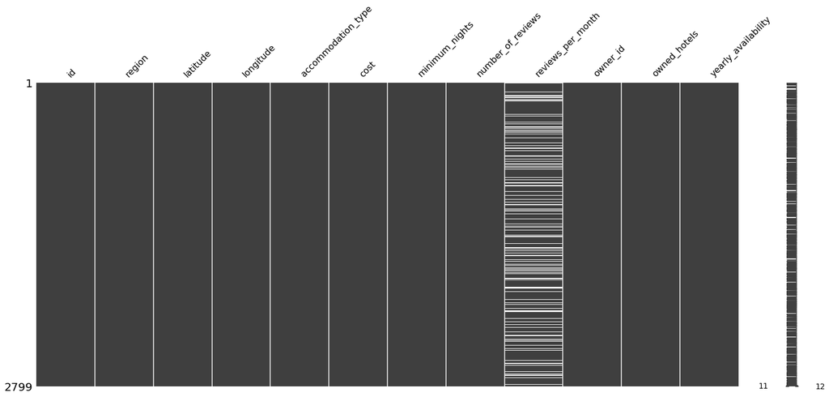

```python
# Plotting the missing values.
msno.matrix(data)
```

- There are null numbers in the reviews per month column, yet there are no null values in the number of reviews for the hotel. So let's look for the number of reviews for these hotels with null values.

```python
data[data['number_of_reviews']==0]['reviews_per_month'].unique()
```

```
array([nan])
```

```python
data = data.fillna(0)
```

```python
data.info()
```

```
<class 'pandas.core.frame.DataFrame'>
Int64Index: 2799 entries, 0 to 2869
Data columns (total 12 columns):
 #   Column               Non-Null Count  Dtype
---  ------               --------------  -----
 0   id                   2799 non-null   int64
 1   region               2799 non-null   object
 2   latitude             2799 non-null   float64
 3   longitude            2799 non-null   float64
 4   accommodation_type   2799 non-null   object
 5   cost                 2799 non-null   int64
 6   minimum_nights       2799 non-null   int64
 7   number_of_reviews    2799 non-null   int64
 8   reviews_per_month    2799 non-null   float64
 9   owner_id             2799 non-null   int64
 10  owned_hotels         2799 non-null   int64
 11  yearly_availability  2799 non-null   int64
dtypes: float64(3), int64(7), object(2)
memory usage: 284.3+ KB
```

# Exploratory Data Analysis

> As Expedia color is close to Dark Blue, I will be using Ocean Theme as my palette for the data analysis.

```python
data.head()
```

|  | id | region | latitude | longitude | accommodation_type | cost | minimum_nights | number_of_reviews | reviews_per_month | owner_id | owned_hotels | yearly_availability |
| --- | --- | --- | --- | --- | --- | --- | --- | --- | --- | --- | --- | --- |
| 0 | 13232 | Manhattan | 40.71854 | -74.00439 | Entire home/apt | 170 | 5 | 7 | 0.56 | 929983 | 1 | 0 |
| 1 | 246 | Brooklyn | 40.64446 | -73.95030 | Entire home/apt | 65 | 3 | 238 | 2.30 | 281764 | 1 | 0 |
| 2 | 19091 | Queens | 40.78573 | -73.81062 | Private room | 85 | 1 | 0 | 0.00 | 19923341 | 1 | 1 |
| 3 | 34305 | Manhattan | 40.73863 | -73.98002 | Private room | 210 | 30 | 0 | 0.00 | 200380610 | 65 | 1 |
| 4 | 444 | Manhattan | 40.82426 | -73.94630 | Shared room | 75 | 3 | 38 | 0.42 | 745069 | 3 | 1 |

```python
data['yearly_availability'].value_counts()
```

```
0    1431
1    1368
Name: yearly_availability, dtype: int64
```

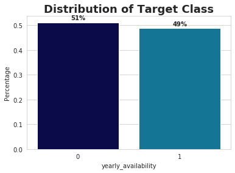

```python
sns.set_style("whitegrid")
plt.title('Distribution of Target Class', fontsize=18, fontweight='bold')
eda_percentage = data['yearly_availability'].value_counts(normalize = True).rename_axis('yearly_availability').reset_index(name = 'Percentage')

ax = sns.barplot(x = 'yearly_availability', y = 'Percentage', data = eda_percentage, palette='ocean')
for p in ax.patches:
    width = p.get_width()
    height = p.get_height()
    x, y = p.get_xy()
    ax.annotate(f'{height:.0%}', (x + width/2, y + height*1.02), ha='center', fontweight='bold')
```

- After dealing with the missing values, the data points with class `1` has fallen 1% low. Still, our dataset is very balanced and can be used for training of the algorithm.

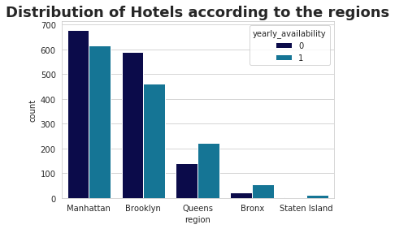

```python
sns.set_style("whitegrid")
plt.title('Distribution of Hotels according to the regions', fontsize=18, fontweight='bold')


ax = sns.countplot(x = 'region', data = data, palette='ocean',hue=data['yearly_availability'])
for p in ax.patches:
    width = p.get_width()
    height = p.get_height()
    x, y = p.get_xy()
```

- From the above visual, we can say that the majority of the hotels are from the region `Manhattan` and `Brooklyn`

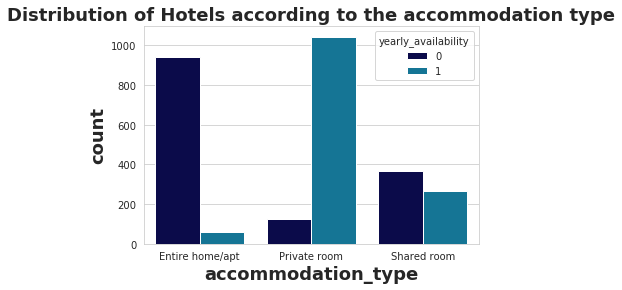

```python
sns.set_style("whitegrid")
plt.title('Distribution of Hotels according to the accommodation type', fontsize=18, fontweight='bold')
plt.xlabel('accommodation_type', fontsize=18, fontweight='bold')
plt.ylabel('Count', fontsize=18, fontweight='bold')

ax = sns.countplot(x = 'accommodation_type', data = data, palette='ocean',hue=data['yearly_availability'])
for p in ax.patches:
    width = p.get_width()
    height = p.get_height()
    x, y = p.get_xy()
```

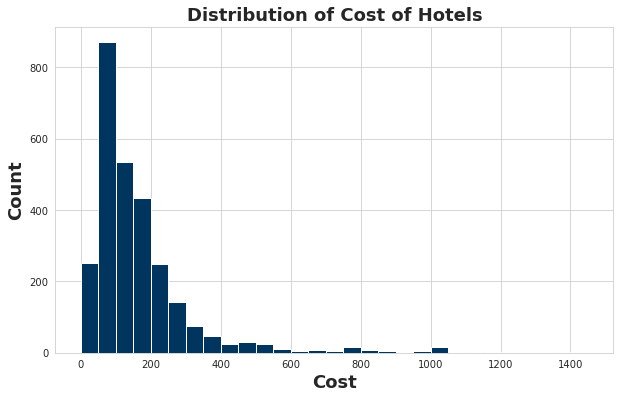

```python
plt.figure(figsize = (10,6))
plt.title('Distribution of Cost of Hotels', fontsize=18, fontweight='bold')
plt.hist(data['cost'], bins=range(0,1500,50), color='#00355F')
plt.xlabel('Cost', fontsize=18, fontweight='bold')
plt.ylabel('Count', fontsize=18, fontweight='bold')
```

- In the above distribution visual, the cost of the hotels look right skewed.
- The majority of hotels charge the customer between the range of `50 - 200`.

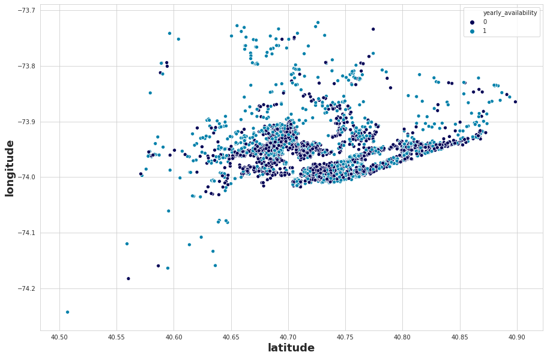

```python
plt.figure(figsize = (15,10))
sns.scatterplot(x = 'latitude', y= 'longitude',hue = 'yearly_availability', data = data , palette = 'ocean')
plt.xlabel('latitude', fontsize=18, fontweight='bold')
plt.ylabel('longitude', fontsize=18, fontweight='bold')
plt.show()
```

## Visualization, Modeling, Machine Learning

Build a model that categorizes hotels on the basis of their yearly availability. Identify how different features influence the decision. Please explain the findings effectively to technical and non-technical audiences using comments and visualizations, if appropriate.

- **Build an optimized model that effectively solves the business problem.**
- **The model will be evaluated on the basis of Accuracy.**
- **Read the test.csv file and prepare features for testing.**

```python
data_corr = data.corr()
```

```python
data_corr['yearly_availability']
```

```
id                    -0.152792
latitude              -0.026472
longitude              0.127107
cost                   0.147515
minimum_nights         0.275268
number_of_reviews     -0.187042
reviews_per_month     -0.304753
owner_id               0.129040
owned_hotels           0.196789
yearly_availability    1.000000
Name: yearly_availability, dtype: float64
```

> Since `Id` is not of any use for training the model and the effect of `latitude` is almost none compared to longitude we are going to drop `Id and latitude` column.

```python
data = data.drop(['id','latitude'],axis=1)
```

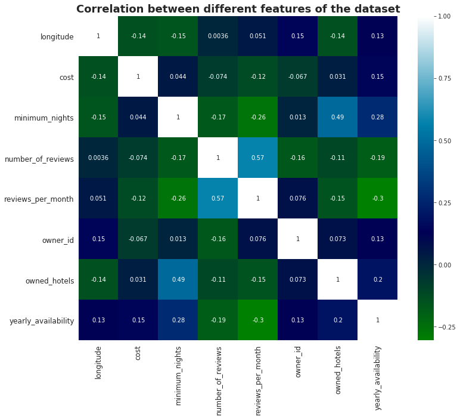

```python
plt.figure(figsize = (12,10))
plt.title("Correlation between different features of the dataset", fontsize = 18, fontweight = 'bold')
sns.heatmap(data.corr(), cmap = 'ocean', annot = True)
plt.xticks(fontsize=12, rotation = 90)
plt.yticks(fontsize=12)
```

## Transformation of the categorical features into numerical classes.

- Label Encoder is used to conver the categorical data set 'region','accommodation_type'] into numerical classes for the algorithms.

```python
categorical = ['region','accommodation_type']
label_encoder = LabelEncoder()
for column in categorical:
    label_encoder.fit(data[column])
    data[column] = label_encoder.transform(data[column])
```

## Splitting the dataset into train test split for modeling.

```python
from sklearn.model_selection import train_test_split

X = data[data.columns[:-1]]
y = data['yearly_availability']

X_train, X_test, y_train, y_test = train_test_split(X, y, test_size = 0.18, random_state = 0)
```

#### Transforming the data into same scale using StandardScaler

- Below, we have transformed the training data into smale scale using Standard Scaler

```python
from sklearn.preprocessing import StandardScaler

std = StandardScaler()

X_train = pd.DataFrame(std.fit_transform(X_train), columns = X.columns)
X_test = pd.DataFrame(std.transform(X_test), columns = X.columns)
```

# Modeling

- In the modeling section, I will be implementing some machine learning algorithms like Logistic Regression, Random Forest Classifier, XG boosting and Gradient Boosting.
- In the Hyper parameter phase, I will usind gridsearchcv to test out the best parameter for the classifiers. Following that, Will use the best model out the them on the test dataset.

# Logistic Regression

```python
lr = LogisticRegression()
param_grid_lr = {'C' : [0.001, 0.01, 0.1, 1.0],
                 'penalty' : ['l1', 'l2']}
gridsearch_lr = GridSearchCV(lr,param_grid = param_grid_lr, cv = 3).fit(X_train,y_train)
gridsearch_lr.best_score_
```

```
0.771677559912854
```

```python
#Accuracy
from sklearn.metrics import accuracy_score
predict_lr = gridsearch_lr.predict(X_test)
accu_lr = accuracy_score(y_test, predict_lr)
print(accu_lr)
```

```
0.7400793650793651
```

# Random forest Classifier

```python
rfc = RandomForestClassifier()
param_grid_rfc = {    'n_estimators': [100,200, 500],
    'max_features': ['auto', 'sqrt', 'log2'],
    'max_depth' : [4,5,6,7,8],
    'criterion' :['gini', 'entropy']}
gridsearch_rfc = GridSearchCV(rfc,param_grid = param_grid_rfc, cv = 3).fit(X_train,y_train)
gridsearch_rfc.best_score_
```

```
0.934640522875817
```

```python
# Accuracy
predict_rfc = gridsearch_rfc.predict(X_test)
accu_rfc = accuracy_score(y_test, predict_rfc)
print(accu_rfc)
```

```
0.9047619047619048
```

# XGBoost Classifier

```python
xgb = XGBClassifier()
param_grid_xgb={'n_estimators': [100],
    'eta': [0.05, 0.1],
    'max_depth': [6],
    'colsample_bytree': [0.4,0.6],
    'gamma': [1.5],
    'tree_method': ['approx']
}
gridsearch_xgb = GridSearchCV(xgb, param_grid = param_grid_xgb, cv= 3).fit(X_train,y_train)
gridsearch_xgb.best_score_
```

[output not shown]

```
0.9359477124183007
```

```python
# Accuracy
predict_xgb = gridsearch_xgb.predict(X_test)
accu_xgb = accuracy_score(y_test, predict_xgb)
print(accu_xgb)
```

```
0.9206349206349206
```

```python
gridsearch_xgb.best_params_
```

```
{'colsample_bytree': 0.6,
 'eta': 0.05,
 'gamma': 1.5,
 'max_depth': 6,
 'n_estimators': 100,
 'tree_method': 'approx'}
```

# Gradient Boosting Classifier

```python
from sklearn.ensemble import GradientBoostingClassifier
gbc = GradientBoostingClassifier()
model_parameters = {'learning_rate' : [0.01, 0.05, 0.1],
                   'max_depth' : [3, 4, 5],
                   'n_estimators' : [100, 150, 200],
                   'max_features' : [5, 7, 9]}
gridsearch_model_gbc = GridSearchCV(gbc, param_grid = model_parameters, cv= 5).fit(X_train,y_train)
```

```python
# Accuracy
predict_gbc = gridsearch_model_gbc.predict(X_test)
accu_gbc = accuracy_score(y_test, predict_gbc)
print(accu_gbc)
```

```
0.9166666666666666
```

# Final Model

- Here we have chosen the XGboostas the best model as our CLassifier.
- We have imported the best parameters from the grid search applied on the XGboost above.
- After Import, we have separetely implemented the model below.

```python
final = XGBClassifier(colsample_bytree= 0.6,
 eta =  0.05,
 gamma = 1.5,
 max_depth =  6,
 n_estimators =  100,
 tree_method = 'approx')
```

```python
final.fit(X_train,y_train)
```

```
[06:12:29] WARNING: ../src/learner.cc:1115: Starting in XGBoost 1.3.0, the default evaluation metric used with the objective 'binary:logistic' was changed from 'error' to 'logloss'. Explicitly set eval_metric if you'd like to restore the old behavior.
```

```
XGBClassifier(base_score=0.5, booster='gbtree', colsample_bylevel=1,
              colsample_bynode=1, colsample_bytree=0.6,
              enable_categorical=False, eta=0.05, gamma=1.5, gpu_id=-1,
              importance_type=None, interaction_constraints='',
              learning_rate=0.0500000007, max_delta_step=0, max_depth=6,
              min_child_weight=1, missing=nan, monotone_constraints='()',
              n_estimators=100, n_jobs=8, num_parallel_tree=1,
              objective='binary:logistic', predictor='auto', random_state=0,
              reg_alpha=0, reg_lambda=1, scale_pos_weight=1, subsample=1,
              tree_method='approx', use_label_encoder=True,
              validate_parameters=1, ...)
```

```python
# Accuracy
predict_xgb_final = final.predict(X_test)
accu_xgb_final = accuracy_score(y_test, predict_xgb_final)
print(accu_xgb_final)
```

```
0.9206349206349206
```

**Highlight the most important features of the model for management.**

#### Task:

> - **Visualize the top 20 features and their feature importance.**
- Here, we have the Important features collected from the model.
- The featues accomodation_type has the mode importance or impact in the prediction of the target class, followed by owned_hotels shown in the visual below.

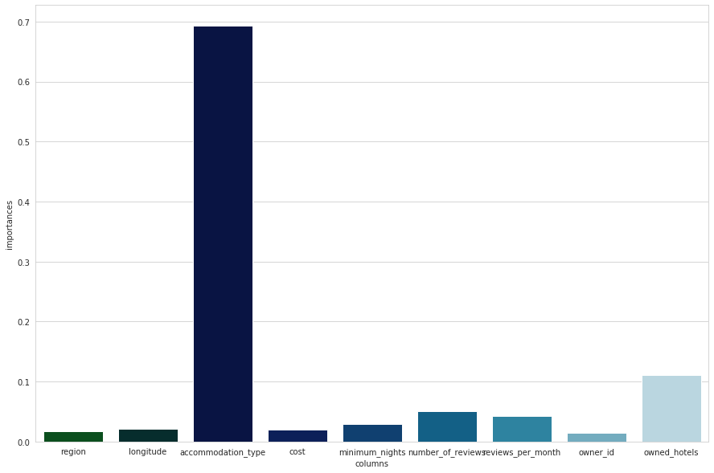

```python
# Visualizing important features
importances = pd.DataFrame({'columns':X_train.columns, 'importances': final.feature_importances_})
plt.figure(figsize = (15,10))
sns.barplot(x = 'columns', y ='importances', data= importances, palette = 'ocean')
plt.show()
```

#### Task:

> - **Submit the predictions on the test dataset using your optimized model**  
>   For each record in the test set (`test.csv`), predict the value of the `yearly_availability` variable. Submit a CSV file with a header row and one row per test entry.

The file (`submissions.csv`) should have exactly 2 columns:

- **id**
- **yearly_availability**

```python
#Loading Test data
test_data=pd.read_csv('test.csv')
test_data.head()
```

|  | id | region | latitude | longitude | accommodation_type | cost | minimum_nights | number_of_reviews | reviews_per_month | owner_id | owned_hotels |
| --- | --- | --- | --- | --- | --- | --- | --- | --- | --- | --- | --- |
| 0 | 19215 | Brooklyn | 40.70912 | -73.94513 | Shared room | 135 | 2 | 22 | 0.66 | 4360212 | 1 |
| 1 | 36301 | Brooklyn | 40.57646 | -73.96641 | Entire home/apt | 69 | 2 | 8 | 0.90 | 181356989 | 2 |
| 2 | 40566 | Manhattan | 40.76616 | -73.98228 | Private room | 225 | 30 | 0 | NaN | 13773574 | 12 |
| 3 | 33694 | Manhattan | 40.77668 | -73.94587 | Shared room | 125 | 30 | 9 | 0.82 | 6788748 | 1 |
| 4 | 28873 | Manhattan | 40.80279 | -73.94450 | Entire home/apt | 43 | 1 | 13 | 0.72 | 105061915 | 2 |

```python
hotel_id = test_data['id']
```

```python
test_data = test_data.drop(['id','latitude'],axis = 1)
```

```python
test_data.info()
```

```
<class 'pandas.core.frame.DataFrame'>
RangeIndex: 718 entries, 0 to 717
Data columns (total 9 columns):
 #   Column              Non-Null Count  Dtype
---  ------              --------------  -----
 0   region              718 non-null    object
 1   longitude           718 non-null    float64
 2   accommodation_type  718 non-null    object
 3   cost                718 non-null    int64
 4   minimum_nights      718 non-null    int64
 5   number_of_reviews   718 non-null    int64
 6   reviews_per_month   545 non-null    float64
 7   owner_id            718 non-null    int64
 8   owned_hotels        718 non-null    int64
dtypes: float64(2), int64(5), object(2)
memory usage: 50.6+ KB
```

```python
test_data = test_data.fillna(0)
```

```python
categorical = ['region','accommodation_type']
label_encoder = LabelEncoder()
for column in categorical:
    label_encoder.fit(test_data[column])
    test_data[column] = label_encoder.transform(test_data[column])
```

```python
prediction_test = final.predict(test_data)
prediction_test
```

```
array([1, 1, 1, 1, 0, 1, 0, 1, 1, 1, 0, 1, 1, 1, 1, 1, 1, 1, 1, 1, 1, 0,
       0, 1, 1, 1, 1, 1, 1, 0, 1, 1, 1, 0, 1, 1, 1, 1, 1, 1, 1, 1, 0, 0,
       1, 1, 1, 0, 1, 1, 0, 0, 0, 1, 0, 1, 1, 0, 1, 1, 0, 1, 0, 1, 1, 1,
       1, 1, 1, 1, 1, 1, 0, 0, 1, 1, 1, 1, 1, 1, 1, 1, 1, 1, 1, 0, 1, 0,
       1, 1, 1, 1, 1, 1, 1, 0, 0, 1, 0, 0, 1, 1, 0, 1, 1, 1, 1, 1, 1, 1,
       0, 0, 1, 1, 1, 1, 0, 0, 1, 1, 1, 1, 1, 0, 1, 0, 0, 1, 1, 1, 1, 1,
       1, 1, 0, 1, 1, 1, 1, 1, 1, 1, 1, 0, 1, 1, 1, 1, 1, 1, 0, 1, 1, 1,
       0, 1, 1, 1, 1, 0, 1, 0, 0, 1, 1, 1, 1, 1, 1, 0, 1, 1, 0, 1, 0, 1,
       1, 1, 1, 1, 1, 1, 0, 1, 1, 1, 0, 1, 1, 0, 1, 1, 1, 1, 0, 1, 0, 1,
       1, 1, 1, 1, 1, 1, 1, 1, 1, 1, 1, 1, 1, 0, 0, 1, 1, 1, 1, 1, 1, 1,
       0, 1, 1, 0, 1, 1, 1, 1, 0, 0, 1, 1, 1, 1, 1, 0, 0, 0, 1, 1, 0, 1,
       1, 0, 1, 1, 0, 1, 1, 0, 1, 0, 0, 0, 1, 0, 1, 0, 1, 1, 1, 1, 1, 1,
       1, 1, 1, 1, 0, 0, 1, 1, 1, 1, 1, 1, 1, 1, 1, 0, 0, 0, 1, 1, 1, 1,
       1, 1, 1, 1, 1, 0, 1, 1, 1, 1, 0, 1, 1, 1, 1, 1, 1, 0, 1, 1, 1, 0,
       1, 1, 1, 1, 1, 0, 1, 1, 0, 1, 1, 1, 1, 1, 1, 1, 1, 0, 1, 0, 1, 0,
```

[output cut: 18 more lines]

```python
submission_df = pd.DataFrame({'id': hotel_id, 'yearly_availability':prediction_test })
```

```python
#Submission
submission_df.to_csv('submissions.csv',index=False)
```